# Election Prediction Model with Prior Setup

2024-04-19

# Goal

Estimate national and state-level trends in support for the candidates

# How

Partially pool two separate predictions:

- a forecast based on historically relevant economic and political factors. (juneapp + q2gdp)
- information from state and national polls during the election season

# Data

https://github.com/TheEconomist/us-potus-model/blob/master/data/

# Model

For individual poll $i$,

$$\begin{equation}
y_i \sim Binomial(\theta_i, n_i)
\end{equation}$$

## Start with a simple model

If poll $i$ is a state-level poll,

$$\begin{equation}
log(\frac{\theta_i}{1-\theta_i}) = \mu^{b}_{s[i],t[i]}
\end{equation}$$

- $\mu^{b}_{s,t}$, which represents the underlying support for the Democrat in state $s$ at time $t$

If poll $i$ is a national-level poll,

$$\begin{equation}
log(\frac{\theta_i}{1-\theta_i}) = \sum_{s=1}^S w_s\mu^{b}_{s,t[i]}
\end{equation}$$

prior:

$$\begin{equation}
\begin{aligned}
\mu_{\mathrm{T}}^{\mathrm{b}} & \sim
\operatorname{MVN}\left(\mu_{t.f.c.}, b_T*\Sigma\right)\\
\mu_{\mathrm{t}}^{\mathrm{b}} \mid \mu_{\mathrm{t}-1}^{\mathrm{b}}
&\sim \operatorname{MVN}\left(\mu_{\mathrm{t}-1}^{\mathrm{b}},
b_0*\Sigma\right)
\end{aligned}
\end{equation}$$

- $\mu_{t.f.c.}$: prediction from time-for-change model

### How to select $b_T, b_0, \Sigma$

Use Informative Prior

Construct $\Sigma$

1. Estimate the correlation matrix using demographics data from different states.
2. Shrink the pairwise correlation by 10% to reflect uncertainty
3. Assume equal standard deviation 7% for each state, the national s.d. is about 5 %.

Construct $b_T$

1. At the beginning of the poll, let $b_T=1$; at the election day, use $b_T=0.36$ (national s.d. becomes 60% of the original one , that is, 5*0.6= 3 %)

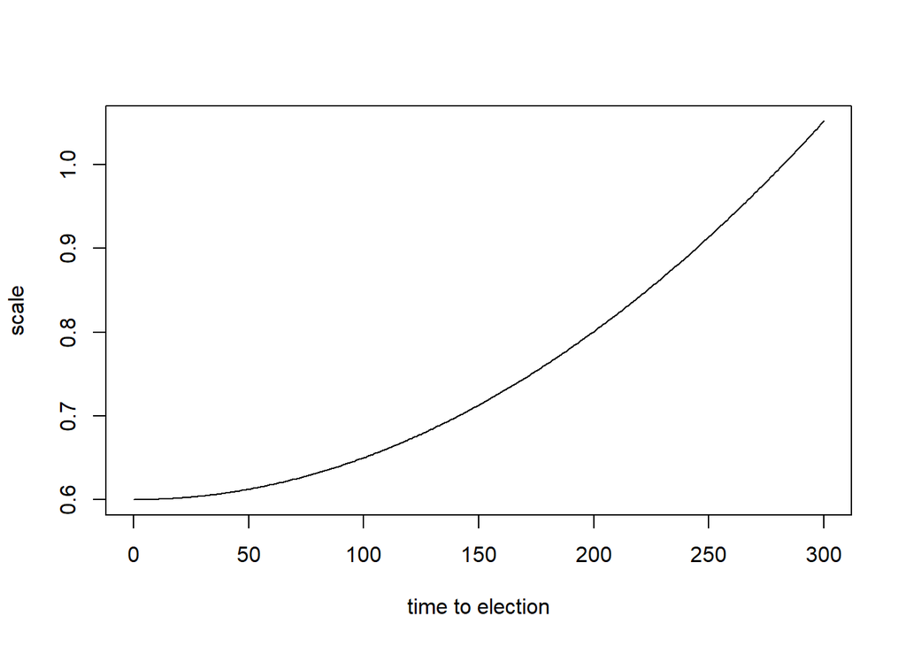

```r
fit_rmse_day_x <- function(x){0.03 +  (10^-6.6)*(x)^2} # fit to error from external script
plot(0:300, fit_rmse_day_x(0:300)/0.05,xlab="time to election",ylab="scale",type="l")
```

2. Transform to the logit scale. $b_T = b_T * 4$

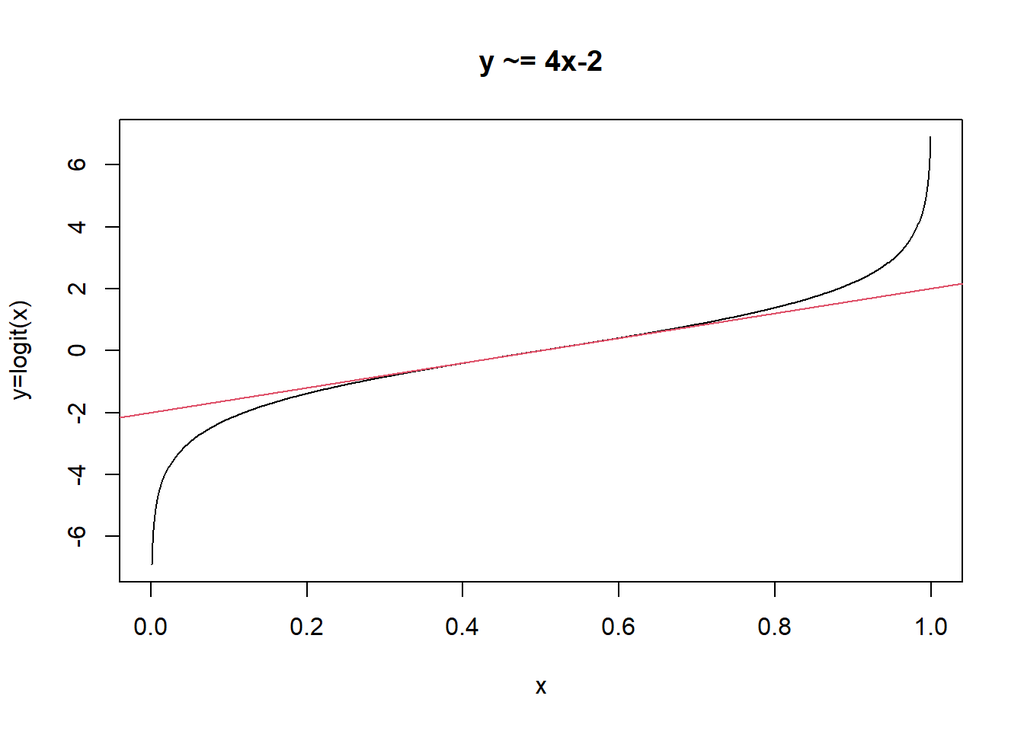

```r
a <- seq(0,1,length.out=1000)
plot(a,log(a/(1-a)),xlab="x",ylab="y=logit(x)",type="l", main="y ~= 4x-2")
abline(-2,4,col=2)
```

Construct $b_0$

1. Use 1/sqrt(300), roughly 0.05. (5*0.05=0.25%). The change will be within 0.5% between neighboring days.
2. Transform to the logit scale. $b_0 = b_0 * 4$

## Consider bias $\alpha_i$ from different sources

state-level poll:

$$\begin{equation}
log(\frac{\theta_i}{1-\theta_i}) = \mu^{b}_{s[i],t[i]} + \alpha_i
\end{equation}$$
national-level poll:

$$\begin{equation}
log(\frac{\theta_i}{1-\theta_i}) = \sum_{s=1}^S w_s\mu^{b}_{s,t[i]}+
\alpha_i
\end{equation}$$

bias decomposition:

$$\begin{equation}
\alpha_{\mathrm{i}}=\mu_{\mathrm{p}[\mathrm{i}]}^{\mathrm{c}}+\mu_{\mathrm{r}[\mathrm{i}]}^{\mathrm{r}}+\mu_{\mathrm{m}[\mathrm{i}]}^{\mathrm{m}}+\mathrm{z_i}
\epsilon_{\mathrm{t}[\mathrm{i}]}
\end{equation}$$

- $\mu^c$: house effects. A polling organization’s results lean in favor of one party.
- $\mu^r$: polling population effects. Effects caused by different population. (e.g. likely voters and registered voters)
- $\mu^m$: polling mode effects. (e.g. live caller or online)
- $z_i$: equal to 1 if the pollster does not adjust for partisanship and 0 otherwise
- $\epsilon_t$: non-response bias at time $t$

prior:

$$\begin{equation}
\begin{aligned}
\mu^{\mathrm{c}}_c & \sim \operatorname{Normal}\left(0,
\sigma^{\mathrm{c}}\right) \\
\mu^{\mathrm{r}}_r & \sim \operatorname{Normal}\left(0,
\sigma^{\mathrm{r}}\right) \\
\mu^{\mathrm{m}}_m & \sim \operatorname{Normal}\left(0,
\sigma^{\mathrm{m}}\right)
\end{aligned}
\end{equation}$$
$$\begin{equation}
\begin{gathered}
\epsilon_1 \mid \rho, \sigma^{\epsilon} \sim
\operatorname{Normal}\left(0, \frac{1}{\sqrt{1-\rho^2}}
\sigma^{\epsilon}\right) \\
\epsilon_{\mathrm{t}} \mid \epsilon_{\mathrm{t}-1}, \rho,
\sigma^{\epsilon} \sim \operatorname{Normal}\left(\rho
\epsilon_{\mathrm{t}-1}, \sigma^{\epsilon}\right) \text { for }
\mathrm{t}=2, \ldots, \mathrm{T} \\
\rho \sim \operatorname{Nnormal}(0.7,0.1) .
\end{gathered}
\end{equation}$$
This prior put most of the probability mass on stationary series, as the non-response bias is not very likely to follow a random walk.

prior (logit scale):

- $\sigma_c = 0.06$. 1.5% s.d. for house effects
- $\sigma_r = 0.04$. 1% s.d. for population effects
- $\sigma_m = 0.04$. 1% s.d. for population effects
- $\sigma_e = 0.02$. 0.5% s.d. for non-response bias.

## Consider measurement error $\zeta_i$

state-level poll:

$$\begin{equation}
log(\frac{\theta_i}{1-\theta_i}) = \mu^{b}_{s[i],t[i]} + \alpha_i +
\zeta^{state}_i
\end{equation}$$

national-level poll:

$$\begin{equation}
log(\frac{\theta_i}{1-\theta_i}) = \sum_{s=1}^S w_s\mu^{b}_{s,t[i]}+
\alpha_i+\zeta^{national}_i
\end{equation}$$

prior:

$$\begin{equation}
\begin{aligned}
\zeta_{\mathrm{i}}^{\text {national }} & \sim
\operatorname{Normal}\left(0, \sigma^{\text {national }}\right) \\
\zeta_{\mathrm{i}}^{\text {state }} & \sim
\operatorname{Normal}\left(0, \sigma^{\text {state }}\right)
\end{aligned}
\end{equation}$$

- $\sigma^{national} = 0.04$. 1% s.d. for national measuring error
- $\sigma^{national} = 0.04$. 1% s.d. for state measuring error

## Consider polling error

state-level poll:

$$\begin{equation}
log(\frac{\theta_i}{1-\theta_i}) = \mu^{b}_{s[i],t[i]} + \alpha_i +
\zeta^{state}_i + \xi_{s[i]}
\end{equation}$$

national-level poll:

$$\begin{equation}
log(\frac{\theta_i}{1-\theta_i}) = \sum_{s=1}^S w_s\mu^{b}_{s,t[i]}+
\alpha_i+\zeta^{national}_i +
\sum_{s=1}^S w_s \xi_s
\end{equation}$$

prior:

$$\begin{equation}
\xi \sim \operatorname{MVN}\left(0, b_{\xi}*\Sigma\right)
\end{equation}$$

Construct $b_{\xi}$

```r
err <- c(0.5, 1.9, 0.8, 7.2, 1.0, 1.4, 0.1, 3.3, 3.4, 0.9, 0.3, 2.7, 1.0) / 2
sqrt(mean(err^2))
```

```
## [1] 1.322512
```

2. Transform to the logit scale. $b_{\xi} = b_{\xi} * 4$